# exercise1

### Computational Physics (SS2020) Exercise 1

### Berat Ertural 406055

#### 1. Derivative Formula

Let $h$ be constant and let $f(x-2h),f(x-h),f(x+h),f(x+2h)$ contain the Taylor expansion up to order 4 with the error term in $O(h^5)$. We first construct the following; \begin{equation} f(x+h) + f(x-h) = 2f(x)+h^2 f^{''}(x)+ \frac{h^4}{12} f^{''''}(x) + O(h^6) \end{equation} Obtaining an error bound in $O(h^6)$ since derivatives of uneven order cancel out. Similarily we get; \begin{equation} f(x+2h) + f(x-2h) = 2f(x)+4 h^2 f^{''}(x)+ \frac{16 h^4}{12} f^{''''}(x) +O(h^6) \end{equation}

Multplying equation (1) by 16 and subtracting equation (2) we get the desired result; \begin{equation} -f(x+2h)+16f(x+h)+16f(x-h)-f(x-2h) = 30f(x)+ 12 h^2 f^{''}(x) + O(h^6) \\ \Rightarrow f^{''}(x) = \frac{1}{h^2}[-\frac{1}{12}f(x+2h)+\frac{4}{3}f(x+h)-\frac{5}{2}f(x)+\frac{4}{3}f(x-h)-\frac{1}{12}f(x-2h)] + O(h^4) \end{equation}

Which is a *central 5-point formula* for the second derivative of *4-th order accuracy*.

#### 2. Simpson Rule

The following function evaluates the integral of a given function $f(x)$ on a finite interval $x \in [a,b]$ using a set of $N$ equidistant sample points.

```python
import math

def simpson(f, a, b, n):
    """Approximate the Integral of f in the interval
    between a and b using n equidistant sample points using
    Simpsons rule. The number of sample points can be even or odd."""
    # Enforce oddity
    n = max (n, 2)
    h = (b-a)/(n-1)
    odd_n = n -1 + n%2 # Enforce oddity
    S = f(a) + f(a+(odd_n-1)*h)
    # Integrate over alternating coefficients
    for i in range(1, n-1, 2):
        S += 4*f(a + i * h)
    for i in range(2, n-2, 2):
        S += 2*f(a + i * h)
    S *= h/3
    # Case n even
    if (n%2 == 0):
        S += (h/12)* (5*f(b) + 8*f(b-h) - f(b-2*h))
    return S

simpson(math.sin, 0, math.pi/2, 8)
```

```
0.9999906618321359
```

Now let us consider $sin(x)$ over the interval $[0, \frac{\pi}{2}]$. For the integral we get $S = \int_{0}^{\frac{\pi}{2}} sin(x) dx = 1$. So the deviation from the analytical result for our example is given by $\Delta S = 1 - S_s(h)$, where $S_s(h)$ is our Simpson integral of step-size $h$.

The theoretical discretization error bound for the Simpson rule is given by; \begin{equation} \Delta S = S-S_s(h) \leq \frac{\gamma}{180}(b-a)h^4 \end{equation} where $\gamma \geq |f^{''''}(x)|$ is usually the smallest possible value greater than or equal to the $(n+1)$-th differential of $f(x)$ between the upper and lower interval bound. In our case $\gamma$ equals $1$.

The following code demonstrates the Simpson integration function with the discussed values.

```python
import numpy as np
import matplotlib.pyplot as plt
import scipy.stats as stats

# Theoretical error bound
def deltaSimpson(a, b, n, k):
    return k*((b-a)**5)/(180*(n**4))

# Collect Simpson integrals and errors for different n in [0, pi/2]
n = []
deltaSt = []  # theoretical error
simpsons = []

# Interation Number, Number of Sample Points, S_T(h_n), Delta S
print("{:10} {:10} {:20} {:20}".format("Iteration", "N", "S_s", "Delta S"))
for k in range(1, 8):
    n.append(10**k)
    simpsons.append(simpson(math.sin, 0, math.pi/2, n[k-1]))
    deltaSt.append(deltaSimpson(0, math.pi/2, n[k-1], 1))
    print("{:10} {:10} {:20} {:20}".format(k, n[k-1], simpsons[k-1], deltaSt[k-1]))
```

```
Iteration  N          S_s                  Delta S
         1         10   0.9999984600259557 5.312841749744469e-06
         2        100   1.0000000003102127 5.312841749744469e-10
         3       1000   1.0000000000000344 5.312841749744469e-14
         4      10000   0.9999999999999978 5.312841749744469e-18
         5     100000   0.9999999999999977 5.312841749744469e-22
         6    1000000   1.0000000000000517 5.312841749744469e-26
         7   10000000   0.9999999999999992 5.312841749744469e-30
```

```
1 - 0.9999984600259557 = 1.53997404428452e-06
1 - 1.0000000003102127 = 3.102127443810332e-10
1 - 1.0000000000000344 = 3.441691376337985e-14
1 - 0.9999999999999978 = 2.220446049250313e-15
1 - 0.9999999999999977 = 2.3314683517128287e-15
1 - 1.0000000000000517 = 5.1736392947532295e-14
1 - 0.9999999999999992 = 7.771561172376096e-16
```

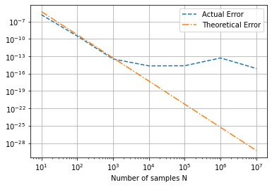

```python
# Actual error is 1 - S_T(h)
deltaSa = [] # actual error
for i in simpsons:
    print("1 - {} = {}".format(i, abs(1-i)))
    deltaSa.append(abs(1-i))
line1, = plt.plot(n, deltaSa, '--', label='Actual Error')
line2, = plt.plot(n, deltaSt, '-.', label='Theoretical Error')
# Log-Log plot of actual error versus theoretical error
plt.grid()
plt.xscale("log")
plt.yscale("log")
plt.xlabel("Number of samples N")
plt.legend(handles=[line1, line2], loc='best')
plt.show()
```

Above is the log-log plot of the actual deviation from the analytical function and the theoretical error bound of the Simpson rule. The actual error (blue) shows artifacts around $10^4$ sample points due to precission errors in $h$ accumulating in the integration function. This is due to the finite internal represention of floating point units in the underlying architecture and the resulting round-off errors for very small fractions.

#### 3. Romberg Integration

Let $R_{n,0}$ be $S_T(h_n)$ as the first column (column number 0) of the Neville scheme. with $S_T(h_n)$ being the n-th order integral using the trapezoidal rule. The recursion relation for column j and row n for the Neville scheme is given by; \begin{equation} R_{n,j} = R_{n,j-1} + \frac{1}{4^j - 1}[R_{n,j-1}-R_{n-1,j-1}]. \end{equation} From this follows; \begin{equation} R_{n,1} = S_T(h_n) + \frac{1}{3}[S_T(h_n)-S_T(h_{n-1})] \end{equation}

To demonstrate the connection of the Neville scheme to the Simpson rule, let us first consider the case for $R_{1,1}$; \begin{equation} R_{1,1} = R_{1,0}+\frac{1}{3}(R_{1,0}-R_{0,0}) \\ = S_T(h_1) + \frac{1}{3}(S_T(h_1)-S_T(h_0)) \\ = \frac{1}{2}S_T(h_0) + h_1 f(a+h_1) - \frac{1}{6}S_T(h_0) + \frac{1}{3}h_1 f(a+h_1)\\ = \frac{1}{3}S_T(h_0) + \frac{4}{3}h_1 f(a+h_1)\\ = \frac{1}{3}(\frac{1}{2}(b-a)(f(a)+f(b))) + \frac{4}{3}h_1 f(a+h_1)\\ \end{equation} Here we can use the fact that $h_{i+1} = \frac{1}{2}h_i$ and $h_0 = b - a$. \begin{equation} R_{1,1} = \frac{1}{3}(h_1(f(a)+f(b))) + \frac{4}{3}h_1 f(a+h_1)\\ = \frac{1}{3}h_1(f(a)+ 4f(a+h_1) + f(b)\\ \end{equation} Which is the integral of the parabola approximating $f$ at the endpoints $a$, $a+h$ and $b$. This is the Simpson rule in its most basic form.

Now let us expand $R_{n,1}$ for any $n$; \begin{equation} R_{n,1} = \frac{1}{3} [ S_T(h_{n-1}) + 4h_n \sum_{i=1}^{2^{n-1}}f(a+(2i-i)h_n) ]\\ = \frac{1}{3} [ (\frac{1}{2}S_T(h_{n-2})+2h_n \sum_{i=1}^{2^{n-2}}f(a+(2i-1)2h_n)) + 4 h_n \sum_{i=1}^{2^{n-1}}f(a+(2i-i)h_n) ]\\ = \frac{1}{3} [ (\frac{1}{2}(\frac{1}{2}S_T(h_{n-3})+4h_n \sum_{i=1}^{2^{n-3}}f(a+(2i-1)4h_n) ))+2h_n \sum_{i=1}^{2^{n-2}}f(a+(2i-1)2h_n)) + 4 h_n \sum_{i=1}^{2^{n-1}}f(a+(2i-1)h_n) ] \end{equation}

After $n$ iterations, we end up with the following; \begin{equation} R_{n,1} = \frac{1}{3}h_n [ \frac{1}{2^n}S_T(h_0) + 2\sum_{j=1}^{n-2} \sum_{i=1}^{2^j} f(a+(2i-1)2^{n-1-j}h_n) + 4 \sum_{i=1}^{2^{n-1}}f(a+(2i-1)h_n) ] = \frac{1}{3}h_n [ f(a) + f(b) + 2\sum_{j=1}^{n-2} \sum_{i=1}^{2^j} f(a+(2i-1)2^{n-1-j}h_n) + 4 \sum_{i=1}^{2^{n-1}}f(a+(2i-1)h_n) ]\\ = \frac{1}{3}h_n [ f(a) + f(b) + 2\sum_{i=1}^{n-2} f(a+ (2i) h_n) + 4 \sum_{i=1}^{2^{n-1}}f(a+(2i-1)h_n) ] \end{equation}

Therefore we can see, that the second column of the Neville scheme corresponds to the Simpson rule, QED.

The following code implements the Romberg integration of the function $f$ in the interval $[a, b]$ using $n$ steps of the Neville scheme.

```python
import numpy

def romberg(f, a, b, n):
    """Romberg integration of f in [a,b] with n levels."""
    h = b-a # Interval size
    Table = numpy.zeros((n, n))
    Table[0][0] = ((h/2) * (f(a) + f(b))) # Insert S_T(h_0)
    # Trapezoidal rule
    for k in range(1,n):
        h /= 2
        # Collect new sample points
        new_samples = 0
        for i in range(1, 2**k, 2):
            new_samples += f(a+i*h)
        Table[k][0] = (Table[k-1][0]/2) + h*new_samples

    # Richardson extrapolation
    for c in range(1, n):
        pow4 = (4**c) - 1
        for r in range(c, n):
            Table[r][c] = Table[r][c-1] + ((Table[r][c-1] - Table[r-1][c-1])/pow4)

    return Table[n-1][n-1]


print(romberg(math.sin, 0, math.pi/2, 10))
```

```
1.0000000000000002
```

We will now examine a few examples. \begin{equation} \int_0^1 e^x dx \approx 1,718281828 \end{equation} \begin{equation} \int_0^{2\pi} sin^4(8x) dx = \frac{3}{4}\pi \end{equation} \begin{equation} \int_0^{1} x^{\frac{1}{2}} = \frac{2}{3} \end{equation}

```python
k = 22
# Tabulate the R_ii for the three test functions for increasing values of i
Rii = numpy.zeros((3, k-2))

print(romberg((lambda x: math.exp(x)),      0, 1,         8))
print(romberg((lambda x: math.sin(8*x)**4), 0, 2*math.pi, 8))
print(romberg((lambda x: math.sqrt(x)),     0, 1,         8))

# go get a coffee
for i in range(2, k):
    Rii[0][i-2] = romberg((lambda x: math.exp(x)),      0, 1,         i)
    Rii[1][i-2] = romberg((lambda x: math.sin(8*x)**4), 0, 2*math.pi, i)
    Rii[2][i-2] = romberg((lambda x: math.sqrt(x)),     0, 1,         i)

# calculate deviation from analytical result
Delta = numpy.zeros((3, k-2))
for i in range(0, k-2):
    Delta[0][i] = abs((math.exp(1)-1) - abs(Rii[0][i]))
    Delta[1][i] = abs(3*math.pi/4 - abs(Rii[1][i]))
    Delta[2][i] = abs((2/3) - abs(Rii[2][i]))
```

```
1.7182818284590449
2.3827353809868543
0.6666193221482841
```

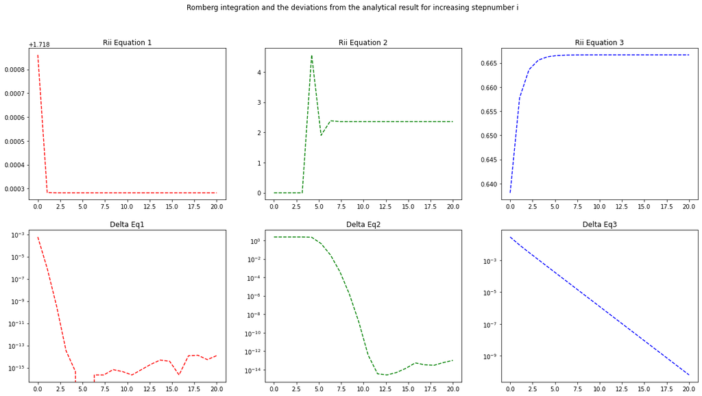

```python
x = np.linspace(0,k-2,k-2)

fig, ((ax11, ax12, ax13), (ax21, ax22, ax23)) = plt.subplots(2, 3)
fig.set_size_inches(20.5, 10.5)
fig.suptitle('Romberg integration and the deviations from the analytical result for increasing stepnumber i')

ax11.plot(x,Rii[0:1].T,'r--')
ax11.set_title("Rii Equation 1")
ax12.plot(x,Rii[1:2].T,'g--')
ax12.set_title("Rii Equation 2")
ax13.plot(x,Rii[2:3].T,'b--')
ax13.set_title("Rii Equation 3")
ax21.plot(x,Delta[0:1].T,'r--')
ax21.set_title("Delta Eq1")
ax22.plot(x,Delta[1:2].T,'g--')
ax22.set_title("Delta Eq2")
ax23.plot(x,Delta[2:3].T,'b--')
ax23.set_title("Delta Eq3")
plt.setp((ax21, ax22, ax23), yscale="log")
plt.show()
```